# Pitching Database Report

Josiah Lovin

February 19, 2019

# Data Acquisition

The database I am exploring is part of “Lahman’s Baseball Database”. I downloaded the database at http://www.seanlahman.com/baseball-archive/statistics/. I saved the database as a Microsoft Excel file. I then loaded and displayed the database into RStudio with the following code:

```r
library(readxl)
Pitching <- read_excel("C:/Users/josia/Documents/DataScienceInR/Projects/Pitching.xlsx")
View(Pitching)
```

# Data Description

Lahman’s Baseball Database contains complete batting and pitching statistics in the MLB from 1871 to 2017. I will be exploring the pitching database. The database includes 30 variables and 45,806 entries. Each entry contains the statistics of one season for a particular pitcher. The first variable, “playerID” identifies the pitcher using a combination of last name, first name, and numbers. The second variable, “yearID”, contains the year/season that correspond with the statistics. “stint” contains the order of appearances within a season. In other words, if a player gets traded in the middle of the season, a new entry is created for the player for the same season and “stint” is incremented by 1. Next, “teamID” identifies the team that the pitcher plays for. The last ID variable is “lgID” which identifies the league that the pitcher is in. The remaining variables are various statistics recorded throughout each season.

# Prominent Features and General Information

I would argue that the most important statistics for a pitcher are Wins/Losses, ERA, and strikeouts. I will go over each stat briefly.

I will begin with the goal of the game: win. The pitcher with the most wins in a season is Charles “Old Hoss” Radbourn with 59. However, a better measure of success would be winning percentage. There are actually 2,757 instances of a pitcher having a season of only wins and no losses. I calculated this with the following code:

```r
WPer <- Pitching$W/(Pitching$W + Pitching$L)
WPer <- WPer[!is.na(WPer)]
sum(WPer == 1)
```

```
## [1] 2757
```

However, even wining percentage is not the best way to calculate success for a pitcher. For example, a pitcher can give up 9 runs but the team can still win 12 - 9. On the other hand, a pitcher can give up 1 run and the team can lose 1 - 0. That is why ERA (Earned Run Average) is the most important stat when it comes to pitching. ERA calculates how many runs you give up per 9 innings. So, if you give up 2 runs in 1 inning, your ERA is 2*9 = 18. This is because if you kept pitching at a rate of 2 runs per inning, you would give up 18 runs. There are plenty of pitchers that have an ERA of 0 for a season. This is because they pitch in 1 or 2 games. I will find the pitcher with the best ERA, but with a minimum of 20 appearances. I will do this by filtering the data set to where G (games) >= 20.

```r
twentyG <- Pitching[Pitching$G >= 20,]
min(twentyG$ERA)
```

```
## [1] 0
```

The minimum ERA is still 0. After closer examination, you can see that there is only one pitcher ever to appear in at least 20 games and have an ERA of 0. This was done by Ty Olson who pitched for the Indians in 2017. He appeared in 30 games. However, he still only pitched 60 innings. Regardless, having an ERA of 0 through 60 innings is not an easy task.

Anyone who knows anything about baseball knows that striking a batter out is the goal of every pitcher. (Some people may argue that it’s better to “pitch to contact”, but we won’t get into baseball philosophy.) After sorting by strikeout, we see that Matt Kilroy had the most in a season with 513 in 1886. However, you are going to have more strikeouts when you pitch more innings. So, we will sort by strikeouts per IPouts (Inning pitched outs, or total outs). We do this by adding a column to the dataframe, KperOut:

```r
Pitching$KperOut <- Pitching$SO/Pitching$IPouts
```

After sorting by KperOut, we see that there are multiple pitchers with a KperOut of 1. However, the highest IPouts out of this group is 6. Thus, the pitcher pitched 6 outs in the season and all 6 were strikeouts. However, that is not a good sample size. Thus, we will require a minimum of 27 IPouts, a full game:

```r
outsTS <- Pitching[Pitching$IPouts >= 27,]
outsTS <- outsTS[!is.na(outsTS$KperOut),]
max(outsTS$KperOut)
```

```
## [1] 0.6756757
```

We see that the highest KperOut is 0.6756757. This was done by Rafael Martin for the Nationals in 2015. He pitched 37 outs that year and over two thirds of them were strikeouts.

# 5 Interesting Trends

One of the first things I noticed when exploring the data was how many games certain pitchers started in the 1800’s. I knew that in the current way the game is played, starting pitchers will start around 25 games per season. However, in the 1800’s two different pitchers started 75 games! So, I found the average of games started by pitchers and grouped them in years of about 30. I then plotted this with a barplot:

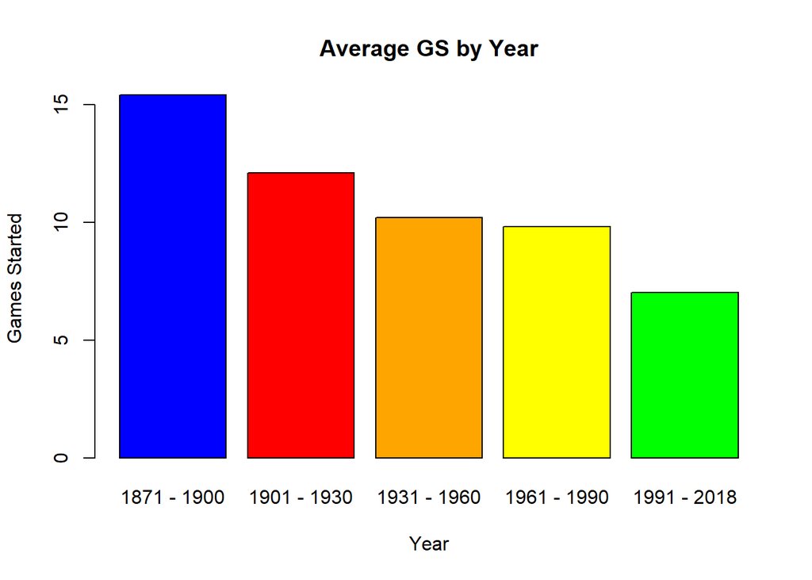

```r
groupOne <- mean(Pitching$GS[Pitching$yearID < 1901])
groupTwo <- mean(Pitching$GS[(Pitching$yearID > 1900) & (Pitching$yearID < 1931)])
groupThree <- mean(Pitching$GS[(Pitching$yearID > 1930) & (Pitching$yearID < 1961)])
groupFour <- mean(Pitching$GS[(Pitching$yearID > 1960) & (Pitching$yearID < 1991)])
groupFive <- mean(Pitching$GS[Pitching$yearID > 1990])
gameStart <- c(groupOne, groupTwo, groupThree, groupFour, groupFive)
barplot(gameStart, names.arg = c("1871 - 1900", "1901 - 1930", "1931 - 1960", "1961 - 1990", "1991 - 2018"), col = c("blue", "red", "orange", "yellow", "green"), main = "Average GS by Year", xlab = "Year", ylab = "Games Started")
```

The average actually decreases each year. I would hypothesize that this is because pitchers that play currently throw much harder than they did in the 1800’s. So, their arms become more sore, thus requiring more days of rest and less starts.

Next, I noticed that saves (SV) correlate with the year. A save is when a pitcher comes into the game when his team has the lead, the pitcher pitches the rest of the game, and his team never loses the lead. Therefore, the pitcher “saves” the game. I did a simple scatter plot of saves by yearID:

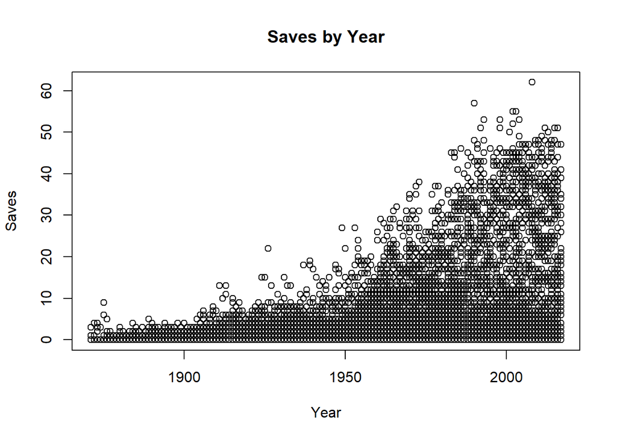

```r
plot(SV ~ yearID, Pitching, main = "Saves by Year", xlab = "Year", ylab = "Saves")
```

As you can see, saves and year form a “J” distribution. I believe this happens for two reasons. The first reason relates to the first interesting feature I found. Pitchers did not throw as hard back then. So, they could throw longer and therefore did not need a pitcher to come in and “save” the game. The second reason is because I believe the strategy of having a “closer” was not implemented until later on. Nowadays, every team has a closer. The closers job is to come in and save the game, therefore earning a save. I believe that once the closer was starting to be used, saves became much more common.

A hot topic around baseball is whether or not the NL (National League) should allow a “designated hitter” (DH). A DH is a batter that specifically hits for the pitcher. They allow this because pitchers specifially focus on pitching which means their hitting is garbage (or at least mine is). The AL (American League), on the other hand, includes a DH in the batting lineups. Because of this, I expected the ERA by pitchers in the AL to be higher than the ERA in the NL. However, after making a box and whisker plot of average ERA, you can see that there is only a slight difference in ERA between the two leagues. I kept the ERA under 10 because extremely high ERAs are usually do to small sample size. Also the DH was not implemented until 1973 so I filtered the data accordingly:

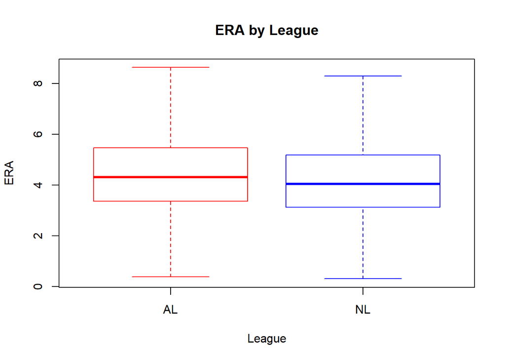

```r
 boxplot(ERA ~ lgID, data = Pitching[(Pitching$lgID == "AL" | Pitching$lgID == "NL") & (Pitching$ERA < 10) & Pitching$yearID >= 1973,], outline = FALSE, border = c("red", "blue"), main = "ERA by League", xlab = "League", ylab = "ERA")
```

I still believe that they should allow DHs in the NL, but this graph is a strong argument against it.

I found another interesting stat by doing some calculations. I calculated my own stat, “Earned Runs per Run”. An earned run is a run that a team “earned” as the name implies. This means that the team scored the run without the other team making an “error”. An error is when the team in the field does not get an easy out. An error could be caused by missing a fly ball, making a bad throw, etc. So, Runs (R) is the totals runs given up, regardless if they were earned or not. So, ERperR calculates the percentage of the total runs given up that were earned. The stat basically tells you how good the fielding was. I found that by grouping the years (as I did in the first feature) and averaging the ERperR, the fielding improved as the years went up:

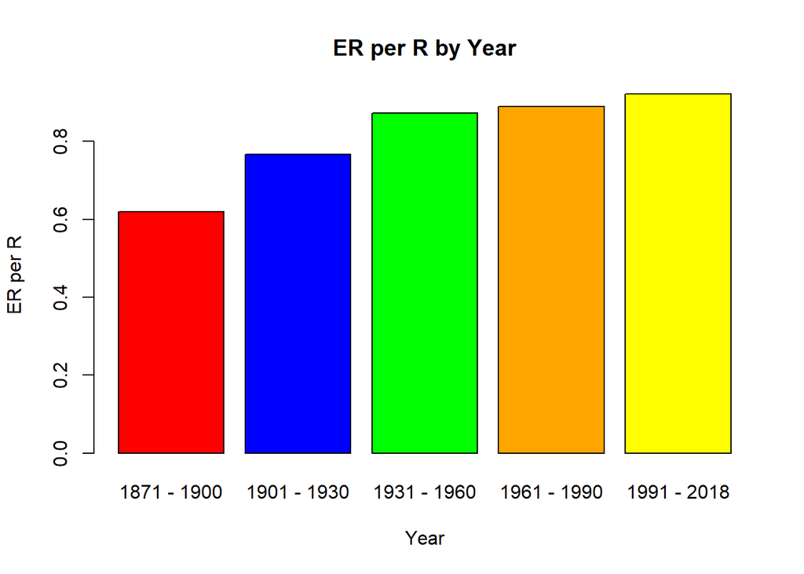

```r
Pitching$ERperR <- Pitching$ER/Pitching$R
groupOne <- mean(Pitching$ERperR[Pitching$yearID < 1901], na.rm = TRUE)
groupTwo <- mean(Pitching$ERperR[Pitching$yearID > 1900 & Pitching$yearID < 1931], na.rm = TRUE)
groupThree <- mean(Pitching$ERperR[Pitching$yearID > 1930 & Pitching$yearID < 1961], na.rm = TRUE)
groupFour <- mean(Pitching$ERperR[Pitching$yearID > 1960 & Pitching$yearID < 1991], na.rm = TRUE)
groupFive <- mean(Pitching$ERperR[Pitching$yearID > 1990], na.rm = TRUE)
groups <- c(groupOne, groupTwo, groupThree, groupFour, groupFive)
barplot(groups, names.arg = c("1871 - 1900", "1901 - 1930", "1931 - 1960", "1961 - 1990", "1991 - 2018"), col = c("red", "blue", "green", "orange", "yellow"), main = "ER per R by Year", xlab = "Year", ylab = "ER per R")
```

Lastly, I examined opponent batting average (BAOpp) to see how it varied over the years. I grouped the years by 30. Note that BAOpp was not recorded until 1901:

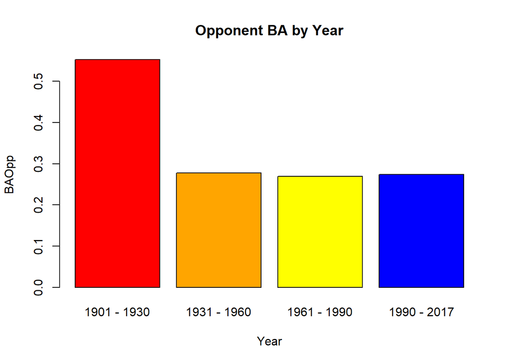

```r
groupOne <- mean(Pitching$BAOpp[Pitching$yearID > 1900 & Pitching$yearID < 1931], na.rm = TRUE)
groupTwo <- mean(Pitching$BAOpp[Pitching$yearID > 1930 & Pitching$yearID < 1961], na.rm = TRUE)
groupThree <- mean(Pitching$BAOpp[Pitching$yearID > 1960 & Pitching$yearID < 1991], na.rm = TRUE)
groupFour <- mean(Pitching$BAOpp[Pitching$yearID > 1990], na.rm = TRUE)
groups <- c(groupOne, groupTwo, groupThree, groupFour)
barplot(groups, names.arg = c("1901 - 1930", "1931 - 1960", "1961 - 1990", "1990 - 2017"), col = c("red", "orange", "yellow", "blue"), main = "Opponent BA by Year", xlab = "Year", ylab = "BAOpp")
```

I cannot think of a reason as to why BAOpp from 1901 - 1930 is so much higher than every other group. My only hypothesis is that pitching (strategy, mechanics, etc.) got substantially better over the years while hitting remained the same.